# FOS course Molecular Data Science: from disease mechanisms to personalized medicine. Transcriptomics - Practicals

Rodrigo Coutinho de Almeida

25/11/2021

In this practical you will analyze RNA-seq data to identify differentially expressed genes (DEGs) in osteoarthritis cartilage. For this purpose, gene expression profiles of articular cartilage samples from osteoarthritis patients were generated with Illumina HiSeq2000 and HiSeq4000. Cartilage samples were collected from patients undergoing total joint replacement surgery due to primary hip or knee osteoarthritis (OA), both, from macroscopically unaffected cartilage regions (*Preserved*) and from affected cartilage regions (*Lesioned*). Analyses will be run in RStudio Cloud

At the end of the practical save as R Markdown file. The file name should also contain your surname(s) and date.

First we need to load the appropriate analysis package. For differential gene expression analysis and normalization we will use the DESeq2 package. Start R Studio Cloud and copy/paste the following commands to load packages for the practical

```r
library(DESeq2)
library(biomaRt)
library(pheatmap)
library(ggplot2)
library(enrichR)
library(limma)
```

Load data for the practical

```r
load("./data/RNASeq_PairedOA_FOS.Rdata")
```

This will load the expression matrix of the OA paired samples (PairsOA) and the phenotype data (pheno) Inspect the loaded data by running the following commands:

```r
head(pheno) # show phenotype data
```

```
##             Patient Trophic_Type    Status     Batch
## S1003.1.COA   S1003     Atrophic    Lesion HiSeq4000
## S1003.1.CP    S1003     Atrophic Preserved HiSeq4000
## S1012.1.COA   S1012     Atrophic    Lesion HiSeq4000
## S1012.1.CP    S1012     Atrophic Preserved HiSeq4000
## S155_OA        S155     Atrophic    Lesion HiSeq2000
## S155_P         S155     Atrophic Preserved HiSeq2000
```

### Question 1.

**a)** What information is provided?

```r
colnames(pheno)
```

```
## [1] "Patient"      "Trophic_Type" "Status"       "Batch"
```

**b)** How many samples are in the dataset? How many unique individuals?

```r
dim(PairsOA_all)
```

```
## [1] 3000   70
```

```r
length(unique(rownames(pheno)))
```

```
## [1] 70
```

**c)** How many lesioned and how many preserved OA?

```r
table(pheno$Status)
```

```
##
##    Lesion Preserved
##        35        35
```

**d)** How many lesioned and how many preserved OA are in batches?

```r
table(pheno$Status, pheno$Batch)
```

```
##
##             HiSeq2000 HiSeq4000
##   Lesion           20        15
##   Preserved        20        15
```

**e)** How many Atrophic and how many Normotrophic patients are in the dataset?

```r
table(pheno$Trophic_Type)
```

```
##
##     Atrophic        NINFO Normotrophic
##           32           10           28
```

### Question 2.

The next steps consist of data and normalization.

**a)** Plot the non-normalized with the commands bellow and explain why is important to normalize your RNA-seq data?

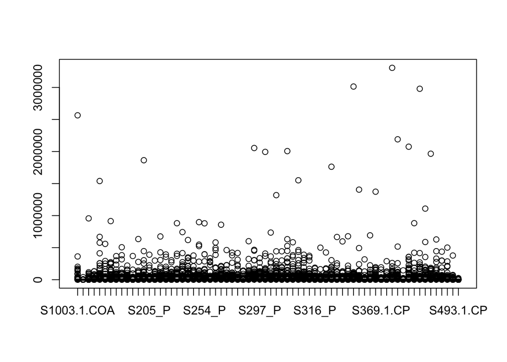

```r
boxplot(PairsOA_all)
```

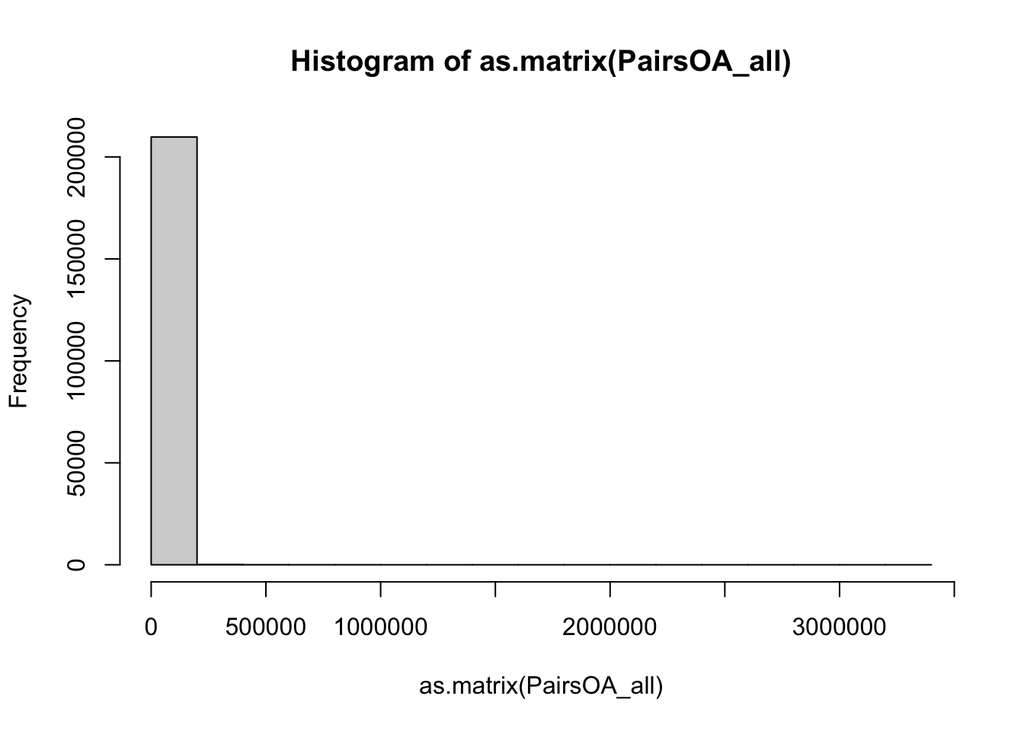

```r
hist(as.matrix(PairsOA_all))
```

**b)** Now normalize the data and plot. Compare the results with the previous plot and explain what happened to your dataset.

```r
ddsGenes <- DESeqDataSetFromMatrix(countData=PairsOA_all,
colData=pheno, design = ~1)
rldGenes <- rlogTransformation(ddsGenes, fitType='local', blind = F)
```

```
## rlog() may take a long time with 50 or more samples,
## vst() is a much faster transformation
```

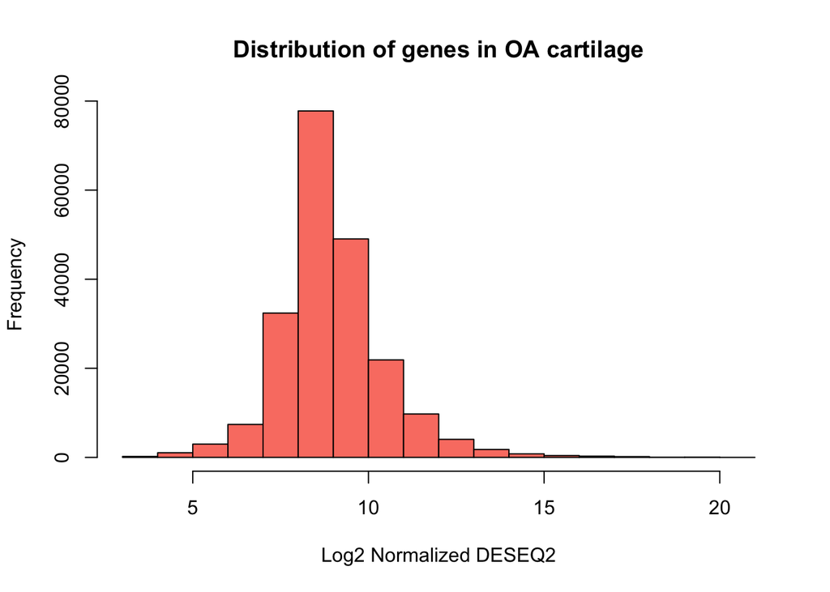

```r
MatrldGenes <- assay(rldGenes)
hist(MatrldGenes, main = "Distribution of genes in OA cartilage", col = "salmon",
xlab = "Log2 Normalized DESEQ2", prob = F)
```

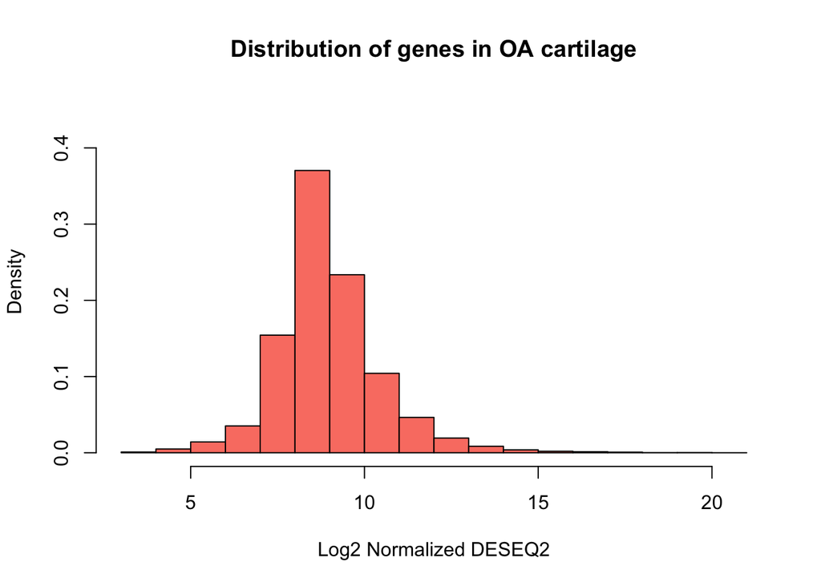

```r
hist(MatrldGenes, main = "Distribution of genes in OA cartilage", col = "salmon",
xlab = "Log2 Normalized DESEQ2", prob = T, ylim = c(0,0.45))
```

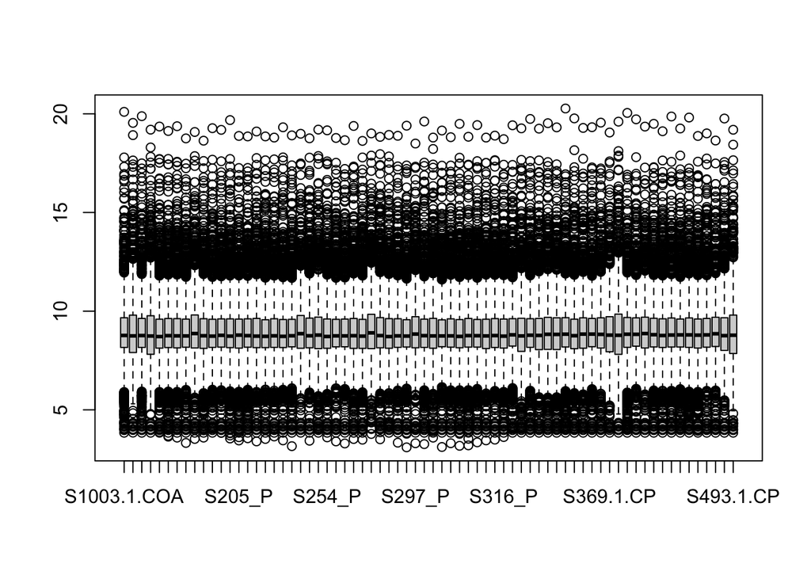

```r
boxplot(MatrldGenes) #plot normalize data
```

**c)** Inspect you data using Principle Component Analysis (PCA), run the following command and report what did you see.

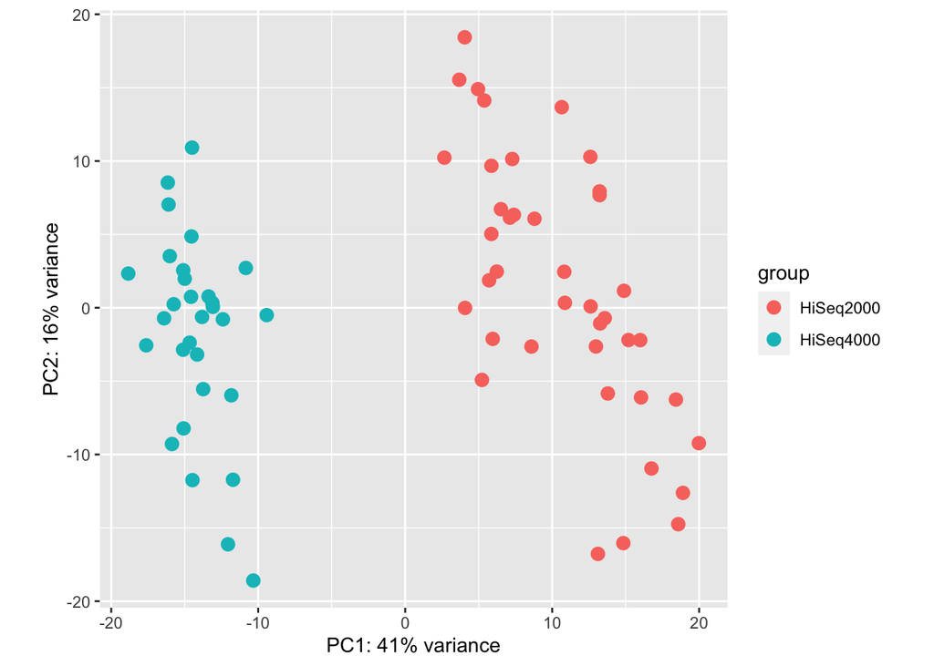

```r
plotPCA(rldGenes, intgroup=c("Batch"))
```

**d)** In case you identified a batch effect, run the following command and plot. Explain what happened to your data. Did you remove all the batch effects?

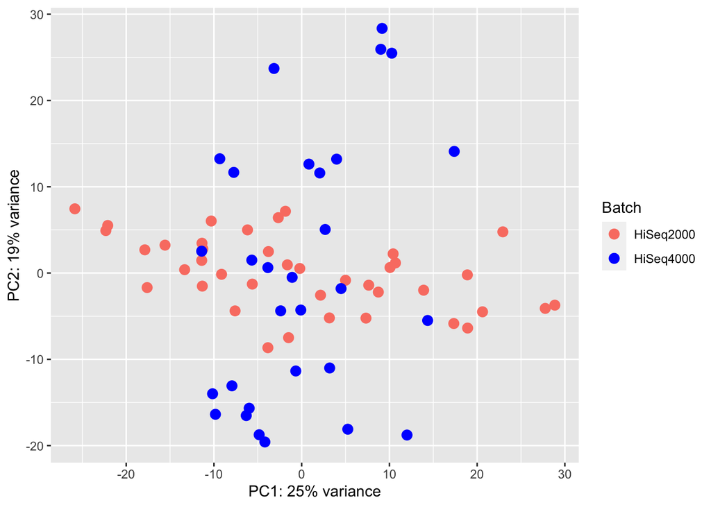

```r
NoBatch <- limma::removeBatchEffect(assay(rldGenes), rldGenes$Batch)
pc <- prcomp(t(NoBatch))
percenVar <- pc$sdev^2/sum(pc$sdev^2)
plotData <- data.frame(pheno, pc$x[,1:3])
p <- ggplot(plotData, aes(x = PC1, y = PC2, colour = Batch))
p + geom_point(size = 3) +
scale_color_manual(values = c("salmon", "blue"))+
xlab(paste0("PC1: ", round(percenVar[1] * 100), "% variance")) +
ylab(paste0("PC2: ", round(percenVar[2] * 100), "% variance"))
```

Now we are ready to perform the actual differential expression analysis. We’re particularly interested in generic gene expression differences between pairs of preserved and OA lesioned cartilage. To analyse this we will perform a pairwise test analysis. Which is done by the following commands:

```r
ddsGenes <- DESeqDataSetFromMatrix(countData=PairsOA_all,
colData=pheno,
design = ~Patient + Status) #Here you build the model take the pairs of patients into account
ddsGenes <- DESeq(ddsGenes)
```

```
## -- note: fitType='parametric', but the dispersion trend was not well captured by the
##    function: y = a/x + b, and a local regression fit was automatically substituted.
##    specify fitType='local' or 'mean' to avoid this message next time.
```

```r
resGenes <- results(ddsGenes)
resGenes <- results(ddsGenes, contrast=c("Status", "Lesion", "Preserved")) #Fold change will be set for Lesion
resGenes <- as.data.frame(resGenes)
resGenes <- resGenes[complete.cases(resGenes),] #take out NA
resGenes <- resGenes[order(resGenes$padj),] #Order according with the P-values (FDR)
resGenes$FC <- 2^resGenes$log2FoldChange #Include an extra column with the fold changes
#Subset the signifcant genes
sigGen <- resGenes[resGenes$padj < 0.05,]
#Change Transcripts ID to Genes Symbols
ensembl=useMart("ensembl")
ensembl = useDataset("hsapiens_gene_ensembl",mart=ensembl)
attributes <- listAttributes(ensembl)
transcriptsids= as.character(rownames(sigGen))
geneIDs <- getBM(attributes = c('ensembl_gene_id', 'external_gene_name'),
filters = 'ensembl_gene_id',
values = transcriptsids,
mart = ensembl)
#Merge and preprocess the data
SignGeneNames <- merge(sigGen,geneIDs,by.x = "row.names",by.y = ,"ensembl_gene_id")
colnames(SignGeneNames)
```

```
## [1] "Row.names"          "baseMean"           "log2FoldChange"
## [4] "lfcSE"              "stat"               "pvalue"
## [7] "padj"               "FC"                 "external_gene_name"
```

```r
SignGeneNames <- SignGeneNames[,c(1,9,8,3,6,7)]
colnames(SignGeneNames)[1:2] <- c("Emsembl_ID", "GeneNames")
SignGeneNames <- SignGeneNames[order(SignGeneNames$padj),]
```

### Question 3. Inspect the output:

**a)** Do you think the batch effect was removed in the differential expression analysis?

*Tip: Remember that you are doing a pairwise analysis*

**b)** Run head(resGenes, n) to inspect the top n genes in your differential expression analysis and use the plotCounts to plot the most significant gene. How many genes after correction and how many genes before the adjustment you observed?

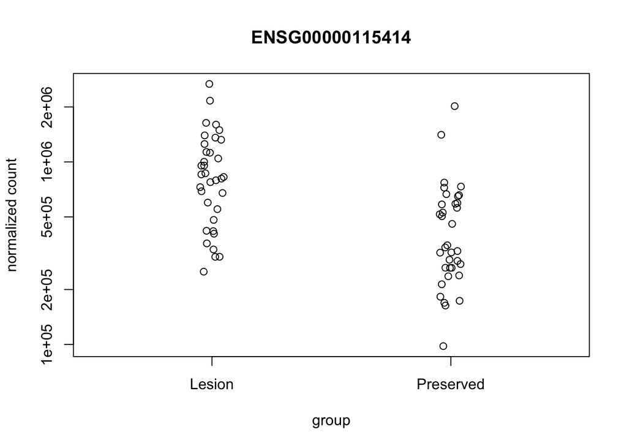

```r
plotCounts(ddsGenes, gene=which.min(resGenes$padj), intgroup="Status")
```

```r
head(resGenes, 10)
```

```
##                  baseMean log2FoldChange     lfcSE      stat       pvalue
## ENSG00000095752 2838.8519       4.469784 0.4379989 10.205012 1.882979e-24
## ENSG00000090530  560.6394       1.637064 0.1645533  9.948537 2.559187e-23
## ENSG00000145824  327.4156       2.213293 0.2504375  8.837705 9.770498e-19
## ENSG00000196352 2736.6817       1.498786 0.1728183  8.672613 4.223160e-18
## ENSG00000002745  248.6473       3.023487 0.3636939  8.313274 9.309714e-17
## ENSG00000164761 3608.7799       1.530030 0.1908239  8.018019 1.074644e-15
## ENSG00000135919 2270.2401       1.361608 0.1748984  7.785139 6.963677e-15
## ENSG00000164929  289.2520       1.257850 0.1621148  7.759009 8.559537e-15
## ENSG00000178752  178.4041       1.731752 0.2272965  7.618913 2.558207e-14
## ENSG00000049192 1128.1261       1.365150 0.1819593  7.502499 6.261260e-14
##                         padj        FC
## ENSG00000095752 5.648936e-21 22.158435
## ENSG00000090530 3.838781e-20  3.110322
## ENSG00000145824 9.770498e-16  4.637326
## ENSG00000196352 3.167370e-15  2.826049
## ENSG00000002745 5.585828e-14  8.131306
## ENSG00000164761 5.373221e-13  2.887918
## ENSG00000135919 2.984433e-12  2.569715
## ENSG00000164929 3.209826e-12  2.391391
## ENSG00000178752 8.527358e-12  3.321310
## ENSG00000049192 1.878378e-11  2.576030
```

```r
str(resGenes)
```

```
## 'data.frame':    3000 obs. of  7 variables:
##  $ baseMean      : num  2839 561 327 2737 249 ...
##  $ log2FoldChange: num  4.47 1.64 2.21 1.5 3.02 ...
##  $ lfcSE         : num  0.438 0.165 0.25 0.173 0.364 ...
##  $ stat          : num  10.21 9.95 8.84 8.67 8.31 ...
##  $ pvalue        : num  1.88e-24 2.56e-23 9.77e-19 4.22e-18 9.31e-17 ...
##  $ padj          : num  5.65e-21 3.84e-20 9.77e-16 3.17e-15 5.59e-14 ...
##  $ FC            : num  22.16 3.11 4.64 2.83 8.13 ...
```

```r
str(SignGeneNames)
```

```
## 'data.frame':    767 obs. of  6 variables:
##  $ Emsembl_ID    : 'AsIs' chr  "ENSG00000095752" "ENSG00000090530" "ENSG00000145824" "ENSG00000196352" ...
##  $ GeneNames     : chr  "IL11" "P3H2" "CXCL14" "CD55" ...
##  $ FC            : num  22.16 3.11 4.64 2.83 8.13 ...
##  $ log2FoldChange: num  4.47 1.64 2.21 1.5 3.02 ...
##  $ pvalue        : num  1.88e-24 2.56e-23 9.77e-19 4.22e-18 9.31e-17 ...
##  $ padj          : num  5.65e-21 3.84e-20 9.77e-16 3.17e-15 5.59e-14 ...
```

```r
length(unique(rownames(resGenes))) - length(unique(rownames(SignGeneNames)))
```

```
## [1] 2233
```

```r
dim(resGenes[resGenes$padj < 0.05,])
```

```
## [1] 767   7
```

```r
dim(resGenes[resGenes$padj > 0.05,])
```

```
## [1] 2233    7
```

**c)** What is the range of differential expression?

```r
#R tips:
  range(resGenes$FC)
```

```
## [1]  0.1254502 22.1584351
```

**d)** Which gene is the most downregulated? Which one is the most upregulated gene? Are they significant after correction for multiple test?

```r
#R tips:
resGenes[which(resGenes$FC %in% range(resGenes$FC)), ]
```

```
##                 baseMean log2FoldChange     lfcSE     stat       pvalue
## ENSG00000095752 2838.852       4.469784 0.4379989 10.20501 1.882979e-24
## ENSG00000054938 1407.960      -2.994814 0.4448538 -6.73213 1.671969e-11
##                         padj         FC
## ENSG00000095752 5.648936e-21 22.1584351
## ENSG00000054938 1.567471e-09  0.1254502
```

**e)** Do you think these changes are biologically relevant?

**f)** How many genes remain if you only consider those with a Fold-change of at least 2?

```r
table(resGenes$FC >=2)
```

```
##
## FALSE  TRUE
##  2952    48
```

```r
table(sigGen$FC >=2)
```

```
##
## FALSE  TRUE
##   720    47
```

**g)** Are the top differentially expressed genes known to be involved in OA? If so, does the direction of differential expression support the reported role in OA?

```r
head(SignGeneNames)
```

```
##          Emsembl_ID GeneNames        FC log2FoldChange       pvalue
## 115 ENSG00000095752      IL11 22.158435       4.469784 1.882979e-24
## 105 ENSG00000090530      P3H2  3.110322       1.637064 2.559187e-23
## 430 ENSG00000145824    CXCL14  4.637326       2.213293 9.770498e-19
## 711 ENSG00000196352      CD55  2.826049       1.498786 4.223160e-18
## 2   ENSG00000002745     WNT16  8.131306       3.023487 9.309714e-17
## 569 ENSG00000164761 TNFRSF11B  2.887918       1.530030 1.074644e-15
##             padj
## 115 5.648936e-21
## 105 3.838781e-20
## 430 9.770498e-16
## 711 3.167370e-15
## 2   5.585828e-14
## 569 5.373221e-13
```

**h)** How about genes not known to be involved in OA, does their in- or decrease in expression make sense in relation to OA?

### Question 4.

To add biological context to your results you can perform a pathway enrichment analysis. Using the following command you will check how your differentially expressed genes are enriched in one branch of the Biological Process from the Gene Ontology database (GO).

```r
dbs <- c("GO_Biological_Process_2017") #Subset a database for the exercise
enriched <- enrichr(SignGeneNames$GeneNames, dbs) #Perform the enrichment analysis
```

```
## Uploading data to Enrichr... Done.
##   Querying GO_Biological_Process_2017... Done.
## Parsing results... Done.
```

```r
head(enriched[["GO_Biological_Process_2017"]]) #Check the results
```

```
##                                                                 Term Overlap
## 1                           skeletal system development (GO:0001501)  26/103
## 2                     extracellular matrix organization (GO:0030198)  29/142
## 3                                platelet degranulation (GO:0002576)  23/122
## 4                    cellular protein metabolic process (GO:0044267)  28/186
## 5                       endodermal cell differentiation (GO:0035987)   10/26
## 6 cellular response to epidermal growth factor stimulus (GO:0071364)    9/23
##        P.value Adjusted.P.value Old.P.value Old.Adjusted.P.value Odds.Ratio
## 1 1.024857e-14     1.682815e-11           0                    0   8.729095
## 2 1.135336e-13     9.321113e-11           0                    0   6.648920
## 3 2.180537e-10     1.193481e-07           0                    0   5.974829
## 4 5.938139e-10     2.437606e-07           0                    0   4.574262
## 5 1.973613e-08     6.481345e-06           0                    0  15.866083
## 6 8.626086e-08     2.360672e-05           0                    0  16.299567
##   Combined.Score
## 1      281.17847
## 2      198.18220
## 3      132.91772
## 4       97.17771
## 5      281.47725
## 6      265.12695
##                                                                                                                                                                                Genes
## 1                    COL12A1;COL11A2;TNFRSF11B;ETS2;PAPSS2;COMP;RPS6KA3;ACAN;EXTL1;ANKH;FRZB;PRDX1;TRPS1;GDF10;POSTN;IGFBP4;IGF2;IGF1;BMP6;TGFBR1;VCAN;BMP1;CDH11;COL9A2;FGFR3;FGFR1
## 2 COL16A1;ITGB5;COL14A1;SERPINE1;TNC;NDNF;FGF2;THBS1;ICAM1;COMP;ACAN;SPP1;ITGAV;CSGALNACT1;LAMB3;LUM;FN1;LAMB1;VCAN;COL7A1;ADAM12;PXDN;MFAP2;COL9A1;COL6A3;COL9A3;COL9A2;ITGA5;MATN4
## 3                                              CHID1;CD63;WDR1;APLP2;SERPINE1;IGF2;FN1;IGF1;LHFPL2;CLU;SYTL4;THBS1;MANF;F5;CD109;SELENOP;PSAP;SERPING1;TIMP3;PHACTR2;TAGLN2;GAS6;VCL
## 4                           SDC2;TNC;MIA3;PRSS23;FSTL1;HSP90B1;FSTL3;C3;STC2;SPP1;IGFBP4;APLP2;IGFBP3;MMP2;IGF2;FN1;LAMB1;IGF1;F5;BACE1;DNAJC3;VCAN;PAPPA;CALU;AMTN;NUCB1;TGFBI;GAS6
## 5                                                                                                                        ITGB5;LAMB3;MMP2;COL7A1;COL12A1;FN1;ITGAV;LAMB1;INHBA;ITGA5
## 6                                                                                                                         STAT5B;FOXC1;ZFP36;SNAI2;IQGAP1;PLCG1;EGFR;ZFP36L2;ZFP36L1
```

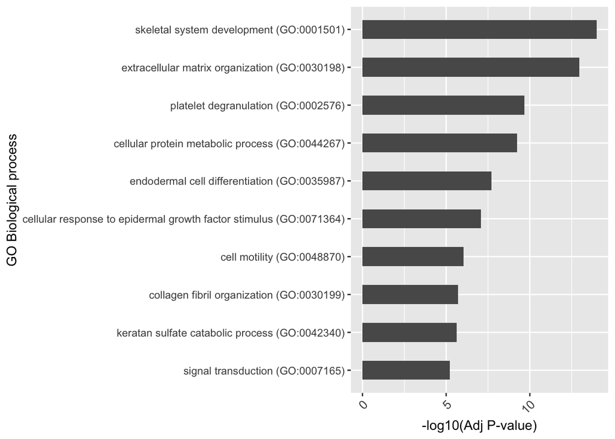

```r
#Here you will preprocess the results to visualize
GOBioProc <- as.data.frame(enriched$"GO_Biological_Process_2017")
GOBioProc$log.Adjpvalue <- -log10(as.numeric(GOBioProc$Adjusted.P.value))
GOBioProc$log.pvalue <- -log10(as.numeric(GOBioProc$P.value))
GOBioProc$Term <- factor(GOBioProc$Term, levels =
GOBioProc$Term[order(GOBioProc$P.value, decreasing = T)])
#Subset only pathways significant after correction for multiple testing
GOBioProc_FDR <- GOBioProc[GOBioProc$Adjusted.P.value <0.05,]
#Plot the top 10 pathways
ggplot(data=GOBioProc_FDR[1:10,], aes(x=Term, y=log.pvalue)) +
geom_bar(stat="identity", position="identity", width = 0.5) + coord_flip() +
theme(axis.text.x = element_text(size = 10, angle = 45,hjust = 1, vjust = 1)) +
labs( x="GO Biological process", y="-log10(Adj P-value)")
```

**a)** How many pathways are significant after correction for multiple testing?

```r
length(unique(GOBioProc_FDR$Term))
```

```
## [1] 118
```

**b)** Which pathway is the most significant? Is this a known pathway in osteoarthritis?

Skeletal system development. Yes.

**c)** How many genes is overlapping in the most significant pathway?

```r
head(GOBioProc_FDR, 5)
```

```
##                                              Term Overlap      P.value
## 1        skeletal system development (GO:0001501)  26/103 1.024857e-14
## 2  extracellular matrix organization (GO:0030198)  29/142 1.135336e-13
## 3             platelet degranulation (GO:0002576)  23/122 2.180537e-10
## 4 cellular protein metabolic process (GO:0044267)  28/186 5.938139e-10
## 5    endodermal cell differentiation (GO:0035987)   10/26 1.973613e-08
##   Adjusted.P.value Old.P.value Old.Adjusted.P.value Odds.Ratio Combined.Score
## 1     1.682815e-11           0                    0   8.729095      281.17847
## 2     9.321113e-11           0                    0   6.648920      198.18220
## 3     1.193481e-07           0                    0   5.974829      132.91772
## 4     2.437606e-07           0                    0   4.574262       97.17771
## 5     6.481345e-06           0                    0  15.866083      281.47725
##                                                                                                                                                                                Genes
## 1                    COL12A1;COL11A2;TNFRSF11B;ETS2;PAPSS2;COMP;RPS6KA3;ACAN;EXTL1;ANKH;FRZB;PRDX1;TRPS1;GDF10;POSTN;IGFBP4;IGF2;IGF1;BMP6;TGFBR1;VCAN;BMP1;CDH11;COL9A2;FGFR3;FGFR1
## 2 COL16A1;ITGB5;COL14A1;SERPINE1;TNC;NDNF;FGF2;THBS1;ICAM1;COMP;ACAN;SPP1;ITGAV;CSGALNACT1;LAMB3;LUM;FN1;LAMB1;VCAN;COL7A1;ADAM12;PXDN;MFAP2;COL9A1;COL6A3;COL9A3;COL9A2;ITGA5;MATN4
## 3                                              CHID1;CD63;WDR1;APLP2;SERPINE1;IGF2;FN1;IGF1;LHFPL2;CLU;SYTL4;THBS1;MANF;F5;CD109;SELENOP;PSAP;SERPING1;TIMP3;PHACTR2;TAGLN2;GAS6;VCL
## 4                           SDC2;TNC;MIA3;PRSS23;FSTL1;HSP90B1;FSTL3;C3;STC2;SPP1;IGFBP4;APLP2;IGFBP3;MMP2;IGF2;FN1;LAMB1;IGF1;F5;BACE1;DNAJC3;VCAN;PAPPA;CALU;AMTN;NUCB1;TGFBI;GAS6
## 5                                                                                                                        ITGB5;LAMB3;MMP2;COL7A1;COL12A1;FN1;ITGAV;LAMB1;INHBA;ITGA5
##   log.Adjpvalue log.pvalue
## 1     10.773964  13.989337
## 2     10.030532  12.944875
## 3      6.923185   9.661437
## 4      6.613037   9.226350
## 5      5.188335   7.704738
```

**d)** How many genes are not significant after correction for multiple test?

```r
#R tips: you can use this code to subset:
dim(GOBioProc[GOBioProc$P.value < 0.05 & GOBioProc$Adjusted.P.value > 0.05,])
```

```
## [1] 263  11
```